# c_bio

```python
import pandas as pd
import numpy as np
import matplotlib.pyplot as plt
import seaborn as sns
from pathlib import Path
data_path = Path("../src")
dataset = Path(data_path / "AnnualCauseDeathNumbers.csv")
data = pd.read_csv(dataset)
```

### En este apartado, estudiaremos las muertes causadas por enfermedades que surgen en las personas.

### En mi opinión, las enfermedades tienden a tener un mayor porcentaje de mortalidad en lugares dónde es díficil acceder a una cura.

### Algunos motivos pueden ser porque la sanidad en ese país no sea pública y el precio de la medicina se encuentre muy alto, o porque el nivel de pobreza del país sea muy elevado.

```python
bio = ['Entity','Year','Meningitis fatalities','Parkinson fatalities','Malaria fatalities','HIV/AIDS fatalities','Tuberculosis fatalities',"Diarrheal disease fatalities","Neoplasm fatalities","Diabetes fatalities","Chronic kidney fatalities","Digestive disease fatalities","Acute hepatitis fatalities","Measles fatalities"]
bio
```

```
['Entity',
 'Year',
 'Meningitis fatalities',
 'Parkinson fatalities',
 'Malaria fatalities',
 'HIV/AIDS fatalities',
 'Tuberculosis fatalities',
 'Diarrheal disease fatalities',
 'Neoplasm fatalities',
 'Diabetes fatalities',
 'Chronic kidney fatalities',
 'Digestive disease fatalities',
 'Acute hepatitis fatalities',
 'Measles fatalities']
```

### Comenzaremos realizando un filtro a la fecha más cercana al día de hoy en el dataset, es decir, 2019.

```python
b2019 = data.query('Year == 2019')
b2019[bio].sample(frac=0.8)
```

|  | Entity | Year | Meningitis fatalities | Parkinson fatalities | Malaria fatalities | HIV/AIDS fatalities | Tuberculosis fatalities | Diarrheal disease fatalities | Neoplasm fatalities | Diabetes fatalities | Chronic kidney fatalities | Digestive disease fatalities | Acute hepatitis fatalities | Measles fatalities |
| --- | --- | --- | --- | --- | --- | --- | --- | --- | --- | --- | --- | --- | --- | --- |
| 3569 | Malta | 2019 | 2 | 52 | 0 | 1 | 1 | 3 | 1002 | 123 | 105 | 124 | 0 | 0 |
| 2669 | Iceland | 2019 | 1 | 37 | 0 | 1 | 1 | 5 | 654 | 26 | 33 | 62 | 0 | 0 |
| 5279 | Seychelles | 2019 | 2 | 6 | 0 | 4 | 4 | 5 | 181 | 26 | 44 | 51 | 0 | 0 |
| 1259 | Congo | 2019 | 284 | 82 | 2102 | 4275 | 1961 | 1879 | 3363 | 1169 | 701 | 1722 | 32 | 156 |
| 2339 | Greece | 2019 | 30 | 1567 | 0 | 22 | 137 | 44 | 35234 | 1366 | 4604 | 4075 | 39 | 0 |
| ... | ... | ... | ... | ... | ... | ... | ... | ... | ... | ... | ... | ... | ... | ... |
| 3419 | Madagascar | 2019 | 2084 | 208 | 5920 | 2530 | 12268 | 18314 | 11011 | 2848 | 1938 | 7189 | 249 | 2279 |
| 6119 | Tunisia | 2019 | 85 | 485 | 0 | 148 | 121 | 121 | 10110 | 1823 | 2634 | 2175 | 87 | 30 |
| 2399 | Grenada | 2019 | 0 | 5 | 0 | 5 | 1 | 1 | 188 | 75 | 50 | 37 | 0 | 0 |
| 2759 | Iran | 2019 | 577 | 2848 | 0 | 1177 | 818 | 962 | 66792 | 14738 | 12546 | 11482 | 466 | 71 |
| 1499 | Democratic Republic of Congo | 2019 | 6147 | 864 | 57160 | 10238 | 46145 | 34003 | 36862 | 11354 | 8034 | 24531 | 1027 | 6607 |

182 rows × 14 columns

### Si investigamos sobre la malaria, encontramos que es una enfermedad infecciosa producida por parásitos y transmitida por mosquitos hembra.

### La malaria es una enfermedad que lleva infectando a los humanos durante más de 50000 años. Era una enfermedad endémica africana hasta que se distribuyo al continente americano con el tráfico de esclavos en el siglo XV.

### La cura de la Malaria está compuesta de un conjunto de medicamentos y antibióticos.

### Por otro lado, la prevención se lleva a cabo con una vacuna, la eliminación de mosquitos y la prevención de picaduras.

### Para comprobar algunas suposiciones, vamos a recolectar datos sobre países africanos como Costa de Marfil.

```python
af = b2019.query('Entity in ["Algeria","Morocco","Zimbabwe","South Africa","Kenya","Cote dIvoire","Botswana","Guinea","Congo","Democratic Republic of Congo","Gabon","Ghana","","Central African Republic","Madagascar","Mozambique","Nigeria","Senegal","Sierra Leona","Somalia",""]')
L = ['Entity','Malaria fatalities']
af[L]
```

|  | Entity | Malaria fatalities |
| --- | --- | --- |
| 119 | Algeria | 0 |
| 779 | Botswana | 14 |
| 1079 | Central African Republic | 4248 |
| 1259 | Congo | 2102 |
| 1349 | Cote dIvoire | 29398 |
| 1499 | Democratic Republic of Congo | 57160 |
| 2189 | Gabon | 715 |
| 2309 | Ghana | 21597 |
| 2489 | Guinea | 11336 |
| 3029 | Kenya | 8049 |
| 3419 | Madagascar | 5920 |
| 3899 | Morocco | 0 |
| 3929 | Mozambique | 20528 |
| 4199 | Nigeria | 191106 |
| 5219 | Senegal | 6740 |
| 5459 | Somalia | 3899 |
| 5489 | South Africa | 464 |
| 6839 | Zimbabwe | 2068 |

### Como observamos, la enfermedad abunda en la parte central de África. Para sacar alguna resolución a futuro, vamos a ver la tendencia que tiene la enfermedad con el paso de los años en las zonas más abundantes.

```python
p_m = ["Cote dIvoire","Democratic Republic of Congo","Ghana","Guinea","Mozambique","Nigeria"]
mal = data.query('Entity in ["Cote dIvoire","Democratic Republic of Congo","Ghana","Guinea","Mozambique","Nigeria"] & Year in [1990,1995,2000,2005,2010,2015,2019]')
l = ['Entity','Year','Malaria fatalities']
```

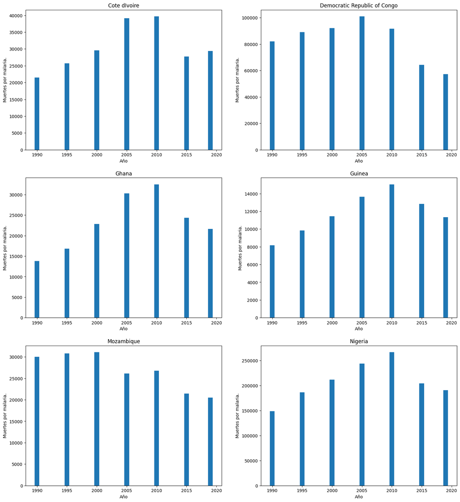

```python
fig, ax = plt.subplots(nrows=3,ncols=2,figsize = (18,20))
agr_mal = mal.groupby(['Entity','Year'])['Malaria fatalities'].mean().unstack().T
i,j = 0,0
for p in p_m:
    ax[i,j].bar(x=agr_mal.index, height=agr_mal[p])
    ax[i,j].set_title(p)
    ax[i,j].set_xlabel('Año')
    ax[i,j].set_ylabel('Muertes por malaria.')
    j += 1
    if j == 2:
        j = 0
        i += 1
```

### El sarampión es otra enfermedad que el humano ha sufrido durante muchisimos años. Es una enfermedad que se propaga de forma respiratoria y es más común en niños. La forma más segura de evitarlo es la vacuna.

### En la siguiente celda, vamos a filtrar los registros entre 1990 y 2019 que más muertos por sarampión tienen.

```python
b90_19 = data.query('Year in [1990,2019]')
b1990 = data.query('Year == 1990')
l1 = ['Entity','Year','Measles fatalities']
m_9019 = b90_19[l1]
m_1990 = b1990[l1]
m_2019 = b2019[l1]
s1990 = m_1990.sort_values(by='Measles fatalities', ascending=False, inplace=False)
s2019 = m_2019.sort_values(by='Measles fatalities', ascending=False, inplace=False)
s9019 = m_9019.sort_values(by='Measles fatalities', ascending=False, inplace=False)
```

### Si nos fijamos a los 10 más altos del año 1990 podemos ver que el sarampión es una enfermedad grave.

```python
s9019[:10]
```

|  | Entity | Year | Measles fatalities |
| --- | --- | --- | --- |
| 6600 | World | 1990 | 801683 |
| 6690 | World Bank Lower Middle Income | 1990 | 485817 |
| 5670 | SubSaharan Africa wb | 1990 | 382050 |
| 30 | African Region who | 1990 | 347385 |
| 5490 | South Asia wb | 1990 | 270728 |
| 6660 | World Bank Low Income | 1990 | 255539 |
| 5580 | SouthEast Asia Region who | 1990 | 232892 |
| 2130 | G20 | 1990 | 221427 |
| 2670 | India | 1990 | 156021 |
| 1680 | Eastern Mediterranean Region who | 1990 | 155888 |

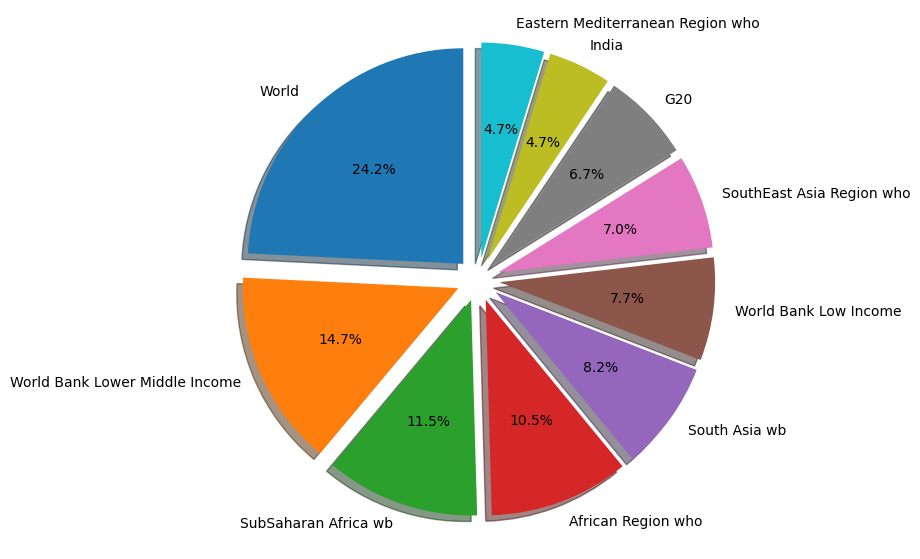

```python
fig, ax = plt.subplots(figsize=((8,7)))
explode =[0.1,0.1,0.1,0.1,0.1,0.1,0.1,0.1,0.1,0.1]
ax.pie(s9019['Measles fatalities'][:10], labels=s9019['Entity'][:10],explode=explode, shadow=True, startangle=90,autopct='%1.1f%%');
```

### En cambio, si filtramos por 2019, podemos fijarnos que el número de muertos es considerablemente más bajo, aunque los países son muy parecidos.

```python
s2019[:10]
```

|  | Entity | Year | Measles fatalities |
| --- | --- | --- | --- |
| 6629 | World | 2019 | 83392 |
| 5699 | SubSaharan Africa wb | 2019 | 65957 |
| 59 | African Region who | 2019 | 57896 |
| 6689 | World Bank Low Income | 2019 | 54867 |
| 6719 | World Bank Lower Middle Income | 2019 | 26533 |
| 1709 | Eastern Mediterranean Region who | 2019 | 13433 |
| 4169 | Niger | 2019 | 10904 |
| 5519 | South Asia wb | 2019 | 9963 |
| 5459 | Somalia | 2019 | 7437 |
| 5609 | SouthEast Asia Region who | 2019 | 7416 |

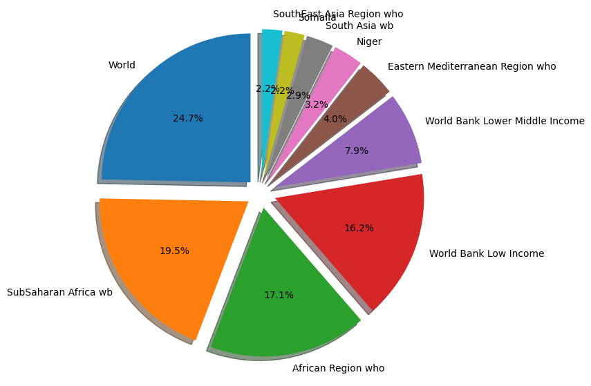

```python
fig, ax = plt.subplots(figsize=((8,7)))
explode =[0.1,0.1,0.1,0.1,0.1,0.1,0.1,0.1,0.1,0.1]
ax.pie(s2019['Measles fatalities'][:10], labels=s2019['Entity'][:10],explode=explode, shadow=True, startangle=90,autopct='%1.1f%%');
```

### Volviendo a la predicción del principio, en estas dos enfermedades podemos ver que los países que tienen cifras son países muy pobres.

### El tiempo de vida humano está aumentando debido a la mejora de todas las vacunas y medicamentos que existen a día de hoy, pero eso es un lujo que solo los países más desarrollados tienen.

### La siguiente enfermedad que vamos a estudiar va a ser la diabetes.

### La diabetes es una enfermedad crónica en la que los niveles de glucosa (azúcar) de la sangre están muy altos, lo que afecta a la forma en que el cuerpo convierte los alimentos en energía. Existen varios tipos de diabetes, según el grado de peligro de la enfermedad.

```python
l2 = ['Entity','Year','Diabetes fatalities']
d9019 = b90_19[l2]
ds9019 = d9019.sort_values(by='Diabetes fatalities', ascending=False, inplace=False)
ds9019[:20]
```

|  | Entity | Year | Diabetes fatalities |
| --- | --- | --- | --- |
| 6629 | World | 2019 | 1551170 |
| 2159 | G20 | 2019 | 995583 |
| 6719 | World Bank Lower Middle Income | 2019 | 690921 |
| 6600 | World | 1990 | 661824 |
| 6749 | World Bank Upper Middle Income | 2019 | 509620 |
| 5609 | SouthEast Asia Region who | 2019 | 475916 |
| 2130 | G20 | 1990 | 440565 |
| 1649 | East Asia & Pacific wb | 2019 | 437697 |
| 5519 | South Asia wb | 2019 | 375647 |
| 4439 | OECD Countries | 2019 | 320617 |
| 4859 | Region of the Americas who | 2019 | 302740 |
| 6599 | Western Pacific Region who | 2019 | 284216 |
| 2699 | India | 2019 | 273089 |
| 6659 | World Bank High Income | 2019 | 252705 |
| 6690 | World Bank Lower Middle Income | 1990 | 224766 |
| 3179 | Latin America & Caribbean wb | 2019 | 221054 |
| 6720 | World Bank Upper Middle Income | 1990 | 210538 |
| 4410 | OECD Countries | 1990 | 205144 |
| 2039 | European Region who | 2019 | 185698 |
| 2009 | Europe & Central Asia wb | 2019 | 181869 |

### Como vemos, se repiten muchos países. Vamos, a comprobar los países con menos muertos.

```python
d9019.sort_values(by='Diabetes fatalities', ascending=True, inplace=False)[:20]
```

|  | Entity | Year | Diabetes fatalities |
| --- | --- | --- | --- |
| 6029 | Tokelau | 2019 | 1 |
| 6000 | Tokelau | 1990 | 1 |
| 4200 | Niue | 1990 | 2 |
| 5070 | San Marino | 1990 | 2 |
| 4229 | Niue | 2019 | 3 |
| 3780 | Monaco | 1990 | 3 |
| 3990 | Nauru | 1990 | 4 |
| 3809 | Monaco | 2019 | 4 |
| 150 | Andorra | 1990 | 4 |
| 2340 | Greenland | 1990 | 5 |
| 5099 | San Marino | 2019 | 5 |
| 4019 | Nauru | 2019 | 6 |
| 2369 | Greenland | 2019 | 6 |
| 6180 | Tuvalu | 1990 | 6 |
| 4500 | Palau | 1990 | 7 |
| 5100 | Sao Tome and Principe | 1990 | 8 |
| 4350 | Northern Mariana Islands | 1990 | 8 |
| 179 | Andorra | 2019 | 9 |
| 5250 | Seychelles | 1990 | 10 |
| 6209 | Tuvalu | 2019 | 11 |

### Cómo es normal, el número de habitantes influye mucho en el número de muertos por la enfermedad. Además, la población de prácticamente todos los países ha ido en aumento, por tanto, debe de haber menos muertos en 1990 que en 2019.

```python
d9019.sort_values(by='Diabetes fatalities', ascending=True, inplace=False)[200:220]
```

|  | Entity | Year | Diabetes fatalities |
| --- | --- | --- | --- |
| 2460 | Guinea | 1990 | 923 |
| 4020 | Nepal | 1990 | 947 |
| 2970 | Kazakhstan | 1990 | 969 |
| 6060 | Trinidad and Tobago | 1990 | 1013 |
| 1079 | Central African Republic | 2019 | 1021 |
| 900 | Burundi | 1990 | 1038 |
| 5430 | Somalia | 1990 | 1041 |
| 5999 | Togo | 2019 | 1046 |
| 1889 | Eritrea | 2019 | 1055 |
| 779 | Botswana | 2019 | 1061 |
| 4319 | North Macedonia | 2019 | 1064 |
| 5820 | Syria | 1990 | 1068 |
| 5309 | Sierra Leone | 2019 | 1095 |
| 2609 | Honduras | 2019 | 1127 |
| 1379 | Croatia | 2019 | 1134 |
| 5700 | Sudan | 1990 | 1137 |
| 6780 | Zambia | 1990 | 1138 |
| 5579 | South Sudan | 2019 | 1143 |
| 3510 | Mali | 1990 | 1144 |
| 1710 | Ecuador | 1990 | 1146 |

### Comprobamos la tendencia de la Diabetes en un país de cada continente.

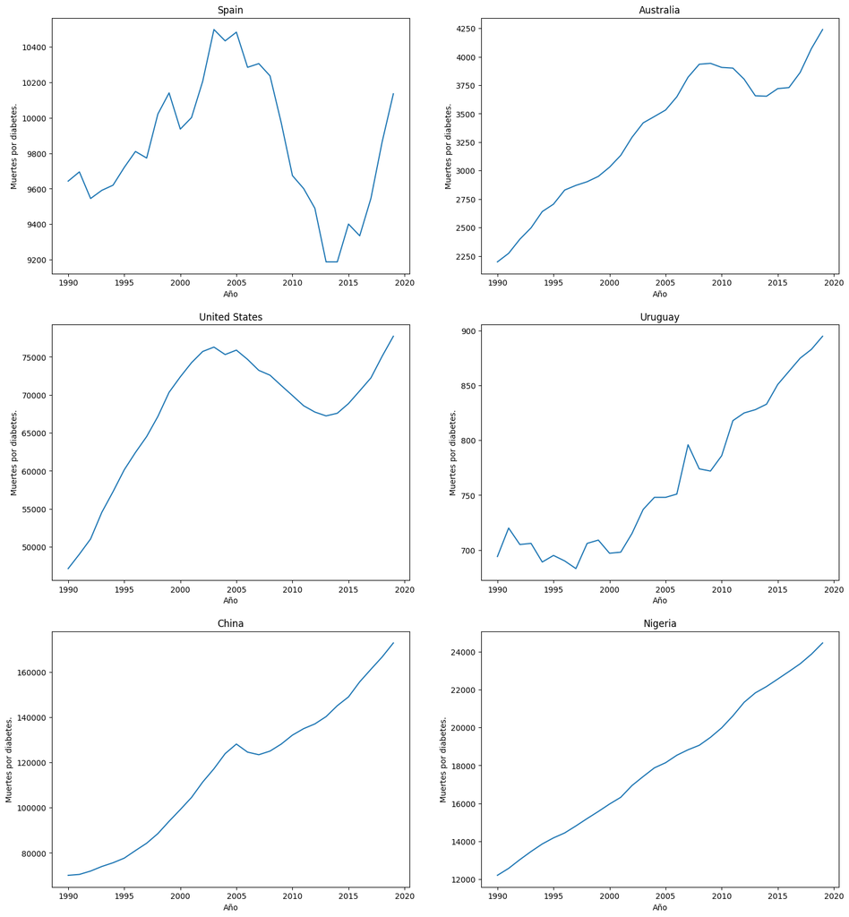

```python
ej = ["Spain","Australia","United States","Uruguay","China","Nigeria"]
L = ['Entity','Year','Diabetes fatalities']
pais = data.query('Entity in ["Spain","Australia","United States","Uruguay","China","Nigeria"]')[L]
agr_p = pais.groupby(['Entity','Year'])['Diabetes fatalities'].mean().unstack().T

fig, ax = plt.subplots(nrows=3,ncols=2,figsize = (18,20))
i,j = 0,0
for e in ej:
    ax[i,j].plot(agr_p.index,agr_p[e])
    ax[i,j].set_title(e)
    ax[i,j].set_xlabel('Año')
    ax[i,j].set_ylabel('Muertes por diabetes.')
    j += 1
    if j == 2:
        j = 0
        i += 1
```

[output not shown]

[figure not shown]

```python
# Datos de ejemplo
paises = ["Spain", "France", "Italy", "Germany", "United Kingdom"]
causas_muerte = ['Meningitis fatalities','Parkinson fatalities','HIV/AIDS fatalities',"Chronic kidney fatalities","Acute hepatitis fatalities"]

mortalidad = data.query('Entity in ["Spain", "France", "Italy", "Germany", "United Kingdom"] & Year == 2019')[causas_muerte]

# Crear el mapa de calor
fig, ax = plt.subplots(figsize=(10, 6))
heatmap = ax.imshow(mortalidad, cmap="YlOrRd")

# Configurar ejes y etiquetas
ax.set_xticks(np.arange(len(causas_muerte)))
ax.set_yticks(np.arange(len(paises)))
ax.set_xticklabels(causas_muerte)
ax.set_yticklabels(paises)
plt.setp(ax.get_xticklabels(), rotation=45, ha="right", rotation_mode="anchor")

# Añadir valores en las celdas
for i in range(len(paises)):
    for j in range(len(causas_muerte)):
        text = ax.text(j, i, ha="center", va="center", color="black")

# Título y etiquetas
ax.set_title("Mortalidad por causas en diferentes países")
plt.xlabel("Causas de muerte")
plt.ylabel("Países")

# Barra de colores
cbar = plt.colorbar(heatmap)
cbar.set_label("Tasa de mortalidad (%)")

plt.show()
```

```python
mortalidad
```

|  | Meningitis fatalities | Parkinson fatalities | HIV/AIDS fatalities | Chronic kidney fatalities | Acute hepatitis fatalities |
| --- | --- | --- | --- | --- | --- |
| 2129 | 226 | 7997 | 457 | 12700 | 19 |
| 2279 | 216 | 12875 | 421 | 35220 | 36 |
| 2879 | 185 | 8036 | 621 | 16513 | 86 |
| 5639 | 155 | 6137 | 679 | 14645 | 14 |
| 6329 | 265 | 7906 | 233 | 7776 | 22 |

### Utilizaremos GeoPandas para ver como se extienden ciertas enfermedades en el mundo.

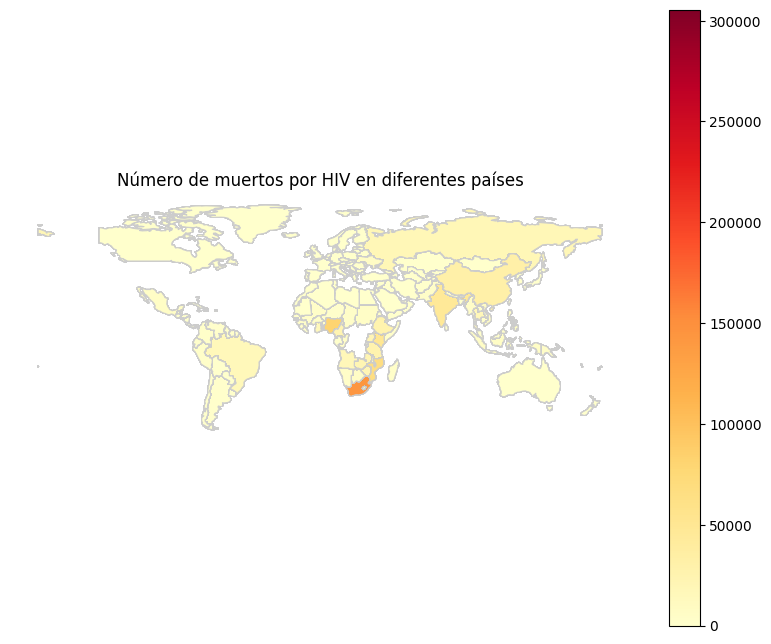

```python
import geopandas as gpd



# Cargar datos geoespaciales (por ejemplo, un archivo shapefile con geometrías de países)
world = gpd.read_file(gpd.datasets.get_path('naturalearth_lowres'))

# Unir datos geoespaciales con tu dataframe
merged_data = world.merge(data, left_on='name', right_on='Entity')

# Crear un mapa de calor
fig, ax = plt.subplots(figsize=(10, 8))
merged_data.plot(column='HIV/AIDS fatalities', cmap='YlOrRd', linewidth=0.8, ax=ax, edgecolor='0.8', legend=True)

# Personalizar el mapa
ax.set_title('Número de muertos por HIV en diferentes países')
ax.set_axis_off()

# Mostrar el mapa
plt.show()
```

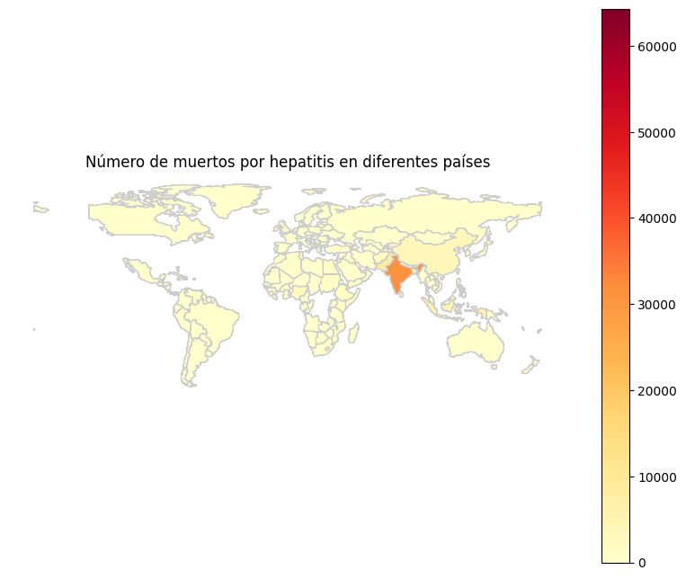

```python
# Cargar datos geoespaciales
world = gpd.read_file(gpd.datasets.get_path('naturalearth_lowres'))

# Unir datos geoespaciales con el dataframe
merged_data = world.merge(data, left_on='name', right_on='Entity')

# Crear un mapa de calor
fig, ax = plt.subplots(figsize=(10, 8))
merged_data.plot(column='Acute hepatitis fatalities', cmap='YlOrRd', linewidth=0.8, ax=ax, edgecolor='0.8', legend=True)

# Personalizar el mapa
ax.set_title('Número de muertos por hepatitis en diferentes países')
ax.set_axis_off()

# Mostrar el mapa
plt.show()
```

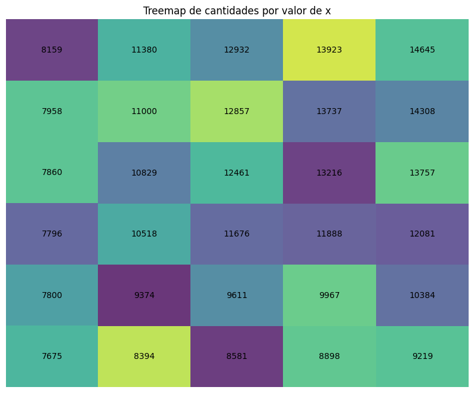

```python
import squarify
spain = data.query('Entity == "Spain"')[bio]
plt.figure(figsize=(10, 8))
squarify.plot(sizes=spain['Year'], label=spain['Chronic kidney fatalities'], alpha=0.8)
plt.axis('off')
plt.title('Treemap de cantidades por valor de x')
plt.show()
```